# STAT353 HW2 GLM

Zeqiu.Yu

## Handwork

*My policy on handwork is that it is required for Statistics PhD students and MS in Statistics students. It is encouraged (but not required) for MS in Applied Statistics and all other students. (If you are the latter, you will not get penalized if you get these wrong … )*

Exercises from the book: 14.1, 14.3, 14.6, 15.2, 15.4.

### 14.1

```r
piValues <- c(0.001, 0.01, 0.05, 0.1, 0.3, 0.5, 0.7, 0.9, 0.95, 0.99, 0.999)
table <- data.frame(piValues, round(piValues*(1-piValues),6))
names(table) <- c("pi","Variance of the error")
table
```

```
##       pi Variance of the error
## 1  0.001              0.000999
## 2  0.010              0.009900
## 3  0.050              0.047500
## 4  0.100              0.090000
## 5  0.300              0.210000
## 6  0.500              0.250000
## 7  0.700              0.210000
## 8  0.900              0.090000
## 9  0.950              0.047500
## 10 0.990              0.009900
## 11 0.999              0.000999
```

I find that the heteroscedasticity is serious when $\pi$ is close to 0 and 1. Also, when $\pi$ is between 0.3 and 0.7, the variance of error is much more steady.

### 14.3

$$\frac{d\pi}{dx} =
\frac{\beta*e^{-(\alpha + \beta x)}}{(1 + e^{-(\alpha + \beta
x)})^2}$$
Lt $u = e^{-(\alpha + \beta x)}, u = \frac{1}{\pi} - 1$, and
$$\frac{d\pi}{dx} = \frac{\beta*u}{(1 + u)^2} =
\beta*(\frac{1}{\pi} - 1)*\pi^2 = \beta\pi(1-\pi)$$
Hence, the slope is $\beta\pi(1-\pi)$.

### 14.6

$$L(\pi, Y) = \Pi_{i= 1}^n
\pi_i^{y_i}(1-\pi_i)^{1-y_i}, after\;\; log,\;\; l = LogL(\pi,Y) =
\sum_{i=1}^{n}y_ilog(\pi_i) + (1-y_i)log(\pi_i)$$
Replace $\pi_i$ with $P_i$, the proof is done.

### 15.2

(a.) p(0) = $\pi_i + (1-\pi_i)e^{-\mu_i}$, and p($y_i$) = $(1-\pi_i)\frac{\mu_i^{y_i}e^{-\mu_i}}{y_i!}$.
Then
$$E(y_i) = 0*p(0) +
\sum_{y_i=1}^{\infty}(1-\pi_i) y_i*p(y_i) =
(1-\pi_i)e^{-\mu_i}\sum_{y_i=1}^{\infty}\frac{y_i}{y_i!}\mu_i^{y_i} =$$
$$=(1-\pi_i)e^{-\mu_i}\mu_i\sum_{y_i=0}^{\infty}\frac{\mu_i^{y_i}}{y_i!}$$
. The series is the expansion of $e^x$. That is$(1-\pi_i)e^{-\mu_i}\mu_ie^{\mu_i} = (1-\pi_i)\mu_i$

$$E(Y_i^2) =(1-\pi_i)\sum_{y_i=1}^{\infty}
y_i^2*p(y_i) =
(1-\pi_i)e^{-\mu_i}\mu_i(\sum_{y_i=0}^{\infty}\frac{\mu_i^{y_i}}{y_i!}*\mu_i
+ \frac{\mu_i^{y_i}}{y_i!}) = (1-\pi_i)\mu_i^2 +
(1-\pi_i)\mu_i$$

Var(Y_i) = $E(Y_i^2) - E(Y_i)^2 = (1-\pi_i)\mu_i(1+\pi_i\mu_i)$ acocording to the equations above.
(b.)
$$L(\beta,\gamma) = \Pi_{y_i=0}(\pi_i +
(1-\pi_i)e^{-\mu_i})\Pi_{y_i>0}(1-\pi_i)\frac{\mu_i^{y_i}e^{-\mu_i}}{y_i!}$$
, and $\pi_i = \frac{exp(z_i^{'}\gamma)}{1+ exp(z_i^{'}\gamma)}$, $\mu_-i = exp(z_i^{'}\beta)$. Then we have:
$$L(\beta,\gamma) =
\Pi_{y_i=0}(exp(z_i^{'}\gamma) + exp(-exp(x_i^{'}\beta))*
\Pi_{i=1}^n\frac{1}{1+exp(z_i^{'}\gamma)}\Pi_{y_i>0}\frac{exp(x_i^{'}\beta)^{y_i}
- exp(-exp(x_i^{'}\beta))}{y_i!}$$
Take log and we get the log-likelihood:
$$l = LogL(\beta, \gamma) =
\sum_{y_i=0}log(exp(z_i^{'}\gamma) + exp(-exp(x_i^{'}\beta))-
\sum_{i=1}^nlog(1+exp(z_i^{'}\gamma)) +
\sum_{y_i>0}(log(exp(x_i^{'}\beta)^{y_i} -
exp(-exp(x_i^{'}\beta))) - log(y_i!))$$

(c.)
According to (a), we have
$$p(y_i;\beta,\gamma) = \pi_i + (1-
\pi_i)\frac{w^w}{(\mu_i+w)^w} = \frac{exp(z_i^{'}\gamma) +
\frac{w^w}{(\mu_i+w)^w}}{ 1+ exp(z_i^{'}\gamma)}, y_i = 0$$
$$p(y_i;\beta,\gamma) =
\frac{1}{1+ exp(z_i^{'}\gamma)}\frac{T(y_i+w)}{y_i!T(w)}\frac{\mu_i^{y_i}w^w}{(\mu_i+w)^w},
y_i >0$$
Above all, we get:
$$LogL(\beta,\gamma) =
\sum_{y_i=0}log(exp(z_i^{'}\gamma) +
\frac{w^w}{(exp(x_i^{'}\beta))^w}) -
\sum_{i=1}^nlog(1+exp(z_i^{'}\gamma)) - \sum_{y_i>0}log(y_i!) +
\sum_{y_i>0}(log\frac{T(y_i+w)}{T(w)}+y_ix_i^{'}\beta -
wlog(\frac{1}{w}exp(x_i^{'}\beta)+1))$$

## Data analysis

### **1. Exercise D14.1 (Dichotomous)**

For this question, we will use the `Chile.txt` dataset, which has a polytomous outcome: voting intention (yes, no, abstain, undecided). For this problem, focus only on the subset of the data with outcomes of either ‘yes’ or ‘no’.

1. Formulate a model that makes substantive sense in the context of the data set - for example,constructing dummy regressors to represent factors and including interaction regressors where these are appropriate - and fit a linear logistic regression of the response variable on the explanatory variables, reporting the estimated regression coefficients and their asymptotic standard errors.

```r
# Load the packages and data
library(faraway)
library(arm)
library(MASS)
library(brant)
library(effects)
library("car")
Chile = na.omit(Chile)
part_chile_set = Chile[Chile$vote %in% c("Y", "N"), ]
```

```r
# Fit the model
fit_logit <- glm(vote ~ age + sex + education + income + statusquo, data = part_chile_set, family = binomial(link = "logit"))
summary(fit_logit)
```

```
##
## Call:
## glm(formula = vote ~ age + sex + education + income + statusquo,
##     family = binomial(link = "logit"), data = part_chile_set)
##
## Deviance Residuals:
##     Min       1Q   Median       3Q      Max
## -3.2634  -0.2838  -0.1358   0.2010   2.9459
##
## Coefficients:
##               Estimate Std. Error z value Pr(>|z|)
## (Intercept)  1.007e+00  3.757e-01   2.680  0.00736 **
## age          1.249e-03  7.419e-03   0.168  0.86632
## sexM        -5.725e-01  2.026e-01  -2.826  0.00471 **
## educationPS -9.605e-01  3.421e-01  -2.807  0.00500 **
## educationS  -6.281e-01  2.415e-01  -2.601  0.00930 **
## income      -2.350e-06  2.783e-06  -0.844  0.39840
## statusquo    3.183e+00  1.468e-01  21.687  < 2e-16 ***
## ---
## Signif. codes:  0 '***' 0.001 '**' 0.01 '*' 0.05 '.' 0.1 ' ' 1
##
## (Dispersion parameter for binomial family taken to be 1)
##
##     Null deviance: 2360.29  on 1702  degrees of freedom
## Residual deviance:  707.52  on 1696  degrees of freedom
## AIC: 721.52
##
## Number of Fisher Scoring iterations: 6
```

From the summary table, we can find the coefficients for age, sex of Male, eduPs. eduS, income status-quo are 0.0012489, -0.5724998, -0.9604655, -0.6281186, -2.3503267^{-6}, 3.1828444 respectively, and corresponding asymptotic standard errors are 0.0074192, 0.2025584, 0.3421308, 0.2415021, 2.7831703^{-6}, 0.1467637.

2. Construct an analysis-of-deviance table for the model fit in part (a).

```r
anova(fit_logit, test="Chisq")
```

```
## Analysis of Deviance Table
##
## Model: binomial, link: logit
##
## Response: vote
##
## Terms added sequentially (first to last)
##
##
##           Df Deviance Resid. Df Resid. Dev  Pr(>Chi)
## NULL                       1702    2360.29
## age        1    34.20      1701    2326.09 4.964e-09 ***
## sex        1    35.64      1700    2290.45 2.372e-09 ***
## education  2    40.79      1698    2249.66 1.392e-09 ***
## income     1    11.35      1697    2238.32  0.000756 ***
## statusquo  1  1530.80      1696     707.52 < 2.2e-16 ***
## ---
## Signif. codes:  0 '***' 0.001 '**' 0.01 '*' 0.05 '.' 0.1 ' ' 1
```

3. Fit a final model to the data that includes the statistically significant effects. Construct an effect display for each high-order term in the model. If the model is additive, (i) suggest two interpretations of each estimated coefficient; and (ii) construct likelihood-ratio-based 95- percent confidence intervals for the regression coefficients, comparing these with confidence intervals based on the Wald statistic.

```r
final <- glm(vote ~ sex + statusquo + education, data = part_chile_set, family = binomial(link = "logit"))
contrast <- glm(vote ~ sex + statusquo + education + education * sex, data = part_chile_set, family = binomial(link = "logit"))
anova(final, contrast,test = "Chisq")
```

```
## Analysis of Deviance Table
##
## Model 1: vote ~ sex + statusquo + education
## Model 2: vote ~ sex + statusquo + education + education * sex
##   Resid. Df Resid. Dev Df Deviance Pr(>Chi)
## 1      1698     708.24
## 2      1696     702.46  2    5.779  0.05561 .
## ---
## Signif. codes:  0 '***' 0.001 '**' 0.01 '*' 0.05 '.' 0.1 ' ' 1
```

```r
summary(final)
```

```
##
## Call:
## glm(formula = vote ~ sex + statusquo + education, family = binomial(link = "logit"),
##     data = part_chile_set)
##
## Deviance Residuals:
##     Min       1Q   Median       3Q      Max
## -3.2553  -0.2845  -0.1297   0.2009   2.9614
##
## Coefficients:
##             Estimate Std. Error z value Pr(>|z|)
## (Intercept)   1.0153     0.1890   5.373 7.75e-08 ***
## sexM         -0.5742     0.2022  -2.840 0.004518 **
## statusquo     3.1689     0.1448  21.886  < 2e-16 ***
## educationPS  -1.1074     0.2914  -3.800 0.000145 ***
## educationS   -0.6828     0.2217  -3.079 0.002077 **
## ---
## Signif. codes:  0 '***' 0.001 '**' 0.01 '*' 0.05 '.' 0.1 ' ' 1
##
## (Dispersion parameter for binomial family taken to be 1)
##
##     Null deviance: 2360.29  on 1702  degrees of freedom
## Residual deviance:  708.24  on 1698  degrees of freedom
## AIC: 718.24
##
## Number of Fisher Scoring iterations: 6
```

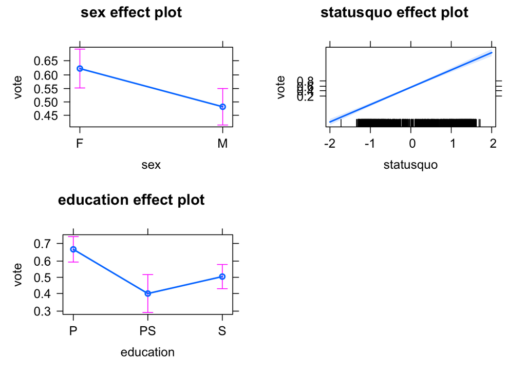

```r
plot(allEffects(final))
```

```r
exp(final$coefficients) # odds ratio
```

```
## (Intercept)        sexM   statusquo educationPS  educationS
##   2.7601091   0.5631303  23.7820368   0.3304143   0.5052234
```

The p-value 0.05561 is not significant for the interaction term, and I will not include this interaction term in the final model. For the interpretation:  
(1.) According to the effect plots, female has a higher expected probability of voting for Pinochet. In addition, people with a primary education have a larger expected probability of voting for Pinochet than people with a secondary and than people with a post-secondary. As the status-quo increases, the probability of voting for Pinochet increases greatly, which is consistent with results of our model.

Using odds ratio, when the other coefficients are 0, the odds of voting for Pinochet is 2.760. When other coefficients remain the same, the odds of voting for Pinochet by male is 0.563x smaller, having a 43.7% reduction in the odds. When other coefficients remain the same, the odds of voting for Pinochet is 23.8x larger with 1 increase in the status-quo.For those with a post secondary education level, the odds of voting for Pinochet is 0.33x smaller, i.e., a 67% reduction in the odds. For those with a secondary education level, the odds of voting for Pinochet is 0.505x smaller, i.e., a 49.5% reduction in the odds.

```r
# likelihood ratio(CIs)
Confint(final)
```

```
##               Estimate      2.5 %     97.5 %
## (Intercept)  1.0152702  0.6493950  1.3910966
## sexM        -0.5742442 -0.9736077 -0.1794437
## statusquo    3.1689305  2.8969991  3.4654718
## educationPS -1.1074079 -1.6875230 -0.5435329
## educationS  -0.6827546 -1.1209148 -0.2502321
```

```r
# Wald Statistics(CIs)
confint.default(final)
```

```
##                  2.5 %     97.5 %
## (Intercept)  0.6449063  1.3856341
## sexM        -0.9706092 -0.1778791
## statusquo    2.8851452  3.4527159
## educationPS -1.6785910 -0.5362247
## educationS  -1.1173685 -0.2481407
```

4. Fit a probit model to the data, comparing the results to those obtained with the logit model. Which do you think is better? Why?

```r
finalProbit = glm(factor(vote) ~ sex + statusquo + education, data = part_chile_set, family = binomial(link = "probit"))
summary(finalProbit)
```

```
##
## Call:
## glm(formula = factor(vote) ~ sex + statusquo + education, family = binomial(link = "probit"),
##     data = part_chile_set)
##
## Deviance Residuals:
##     Min       1Q   Median       3Q      Max
## -3.4890  -0.2838  -0.0933   0.1887   3.0892
##
## Coefficients:
##             Estimate Std. Error z value Pr(>|z|)
## (Intercept)  0.50536    0.09845   5.133 2.85e-07 ***
## sexM        -0.31859    0.10457  -3.047 0.002314 **
## statusquo    1.72754    0.06679  25.865  < 2e-16 ***
## educationPS -0.57146    0.14911  -3.833 0.000127 ***
## educationS  -0.32303    0.11497  -2.810 0.004958 **
## ---
## Signif. codes:  0 '***' 0.001 '**' 0.01 '*' 0.05 '.' 0.1 ' ' 1
##
## (Dispersion parameter for binomial family taken to be 1)
##
##     Null deviance: 2360.3  on 1702  degrees of freedom
## Residual deviance:  708.9  on 1698  degrees of freedom
## AIC: 718.9
##
## Number of Fisher Scoring iterations: 6
```

I think the logit is better according to the AIC score, 718.24 is a little bit smaller than 718.9, and the coefficients of logit models are more interpretable than the probit’s.

### **2. Exercise D14.2 (Polytomous outcome)**

Proceed as in Exercise D14.1, but now include all of the data and the four possible outcome values.

Use, as appropriate, one or more of the following: a multinomial logit model; a proportional odds logit model; logit models fit to a set of nested dichotomies; or similar probit models. If you fit the proportional-odds model, test the assumption of parallel regressions. If you fit more than one kind of model, which model do you prefer? Why?

```r
# multinomial logit model
library(nnet)
fit_mn <- multinom(as.factor(vote) ~ sex + education + statusquo, data = Chile)
summary(fit_mn)
```

```
## Call:
## multinom(formula = as.factor(vote) ~ sex + education + statusquo,
##     data = Chile)
##
## Coefficients:
##   (Intercept)        sexM educationPS educationS  statusquo
## N   0.2016956  0.68525444   0.2680968 -0.2904600 -1.7826982
## U   1.8695231 -0.25458877  -1.2818326 -0.9060812  0.3257245
## Y   1.2861711 -0.08477208  -0.6201763 -0.8468420  1.8873922
##
## Std. Errors:
##   (Intercept)      sexM educationPS educationS statusquo
## N   0.2018706 0.1769543   0.2641526  0.2038259 0.1330020
## U   0.1721533 0.1771652   0.2825563  0.1974378 0.1078507
## Y   0.1863343 0.1846941   0.2827072  0.2071966 0.1217894
##
## Residual Deviance: 4069.1
## AIC: 4099.1
```

```r
# proportional odds logit model
fit_pol <- polr(factor(vote) ~ sex + education + statusquo , data = Chile)
summary(fit_pol)
```

```
##
## Re-fitting to get Hessian
```

```
## Call:
## polr(formula = factor(vote) ~ sex + education + statusquo, data = Chile)
##
## Coefficients:
##               Value Std. Error t value
## sexM        -0.2561    0.08310  -3.082
## educationPS -0.4028    0.11864  -3.395
## educationS  -0.3823    0.09180  -4.164
## statusquo    1.7951    0.05551  32.336
##
## Intercepts:
##     Value    Std. Error t value
## A|N  -4.1043   0.1198   -34.2516
## N|U  -1.1216   0.0863   -12.9931
## U|Y   0.6909   0.0834     8.2797
##
## Residual Deviance: 4577.314
## AIC: 4591.314
```

```r
poTest(fit_pol)
```

```
##
## Tests for Proportional Odds
## polr(formula = factor(vote) ~ sex + education + statusquo, data = Chile)
##
##               b[polr]     b[>A]     b[>N]     b[>U] Chisquare df Pr(>Chisq)
## Overall                                                1156.8  8    < 2e-16 ***
## sexM          -0.2561    0.1944   -0.6674   -0.0528      40.5  2    1.6e-09 ***
## educationPS   -0.4028   -0.3610   -1.2007    0.0479      50.5  2    1.1e-11 ***
## educationS    -0.3823   -0.7040   -0.6946   -0.1726      12.8  2     0.0017 **
## statusquo      1.7951    0.1841    2.0521    2.0986     965.1  2    < 2e-16 ***
## ---
## Signif. codes:  0 '***' 0.001 '**' 0.01 '*' 0.05 '.' 0.1 ' ' 1
```

I use multinomial logit model and proportional ratio logit models, and I prefer multinomial logit model.  
For the parallel regression assumption test, since all the p-values are less than 0.05, we reject the null hypothesis that there is a parallel regression. Hence, the proportional odds model is not appropriate here. In addition, when we compare the deviance between these two models, multinomial logit model has a smaller deviance (4069.1 < 4577.314 as shown in two summary tables above). Hence, the nested model doesn’t works well too. Moreover, there are not nested dichotomies in the vote, since the vote has 4 levels( A: will abstain; N: will vote no (against Pinochet); U: undecided; Y: will vote yes (for Pinochet)).

### **3. Exercise D15.3 (GLM Diagnostics)**

Return to the logit (and probit) model that you fit in Exercise D14.1.

1. Use the diagnostic methods for generalized linear models described in this chapter to check the adequacy of the final model that you fit to the data.

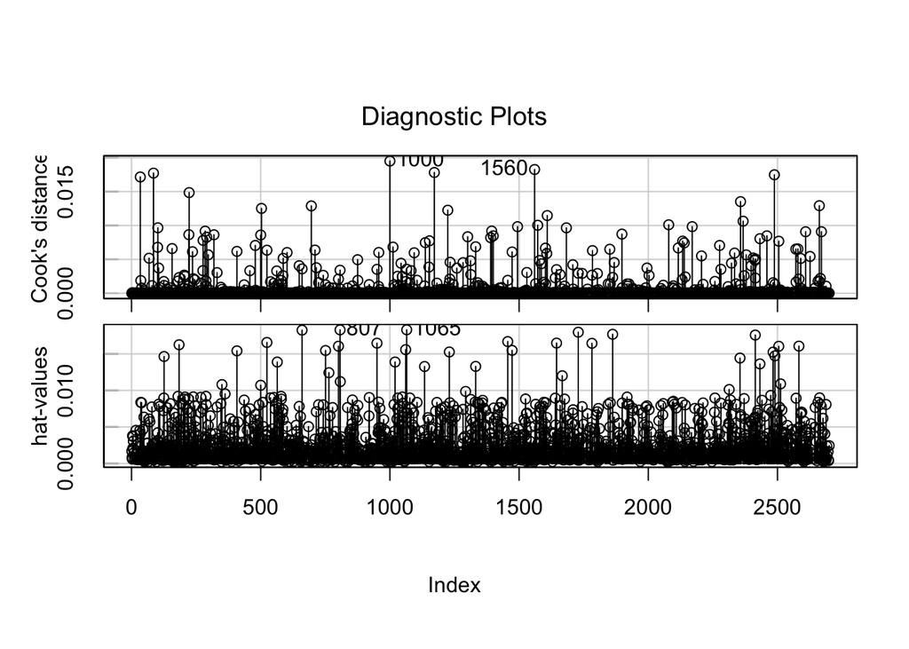

```r
influenceIndexPlot(final, vars = c("Cook","hat"))
```

```r
compareCoefs(final, update(final, subset=-c(1000,1560)))
```

```
## Calls:
## 1: glm(formula = vote ~ sex + statusquo + education, family = binomial(link
##   = "logit"), data = part_chile_set)
## 2: glm(formula = vote ~ sex + statusquo + education, family = binomial(link
##   = "logit"), data = part_chile_set, subset = -c(1000, 1560))
##
##             Model 1 Model 2
## (Intercept)   1.015   1.055
## SE            0.189   0.191
##
## sexM         -0.574  -0.596
## SE            0.202   0.203
##
## statusquo     3.169   3.184
## SE            0.145   0.146
##
## educationPS  -1.107  -1.134
## SE            0.291   0.293
##
## educationS   -0.683  -0.709
## SE            0.222   0.223
##
```

```r
# remove influential points
compareCoefs(final, update(final, subset=-c(1000,1560)))
```

```
## Calls:
## 1: glm(formula = vote ~ sex + statusquo + education, family = binomial(link
##   = "logit"), data = part_chile_set)
## 2: glm(formula = vote ~ sex + statusquo + education, family = binomial(link
##   = "logit"), data = part_chile_set, subset = -c(1000, 1560))
##
##             Model 1 Model 2
## (Intercept)   1.015   1.055
## SE            0.189   0.191
##
## sexM         -0.574  -0.596
## SE            0.202   0.203
##
## statusquo     3.169   3.184
## SE            0.145   0.146
##
## educationPS  -1.107  -1.134
## SE            0.291   0.293
##
## educationS   -0.683  -0.709
## SE            0.222   0.223
##
```

From the diagnostic Plots, we can find two influential points ,and after checking and comparing the coefficients, I find the existence of these two points will not have a large change to the result and analysis.

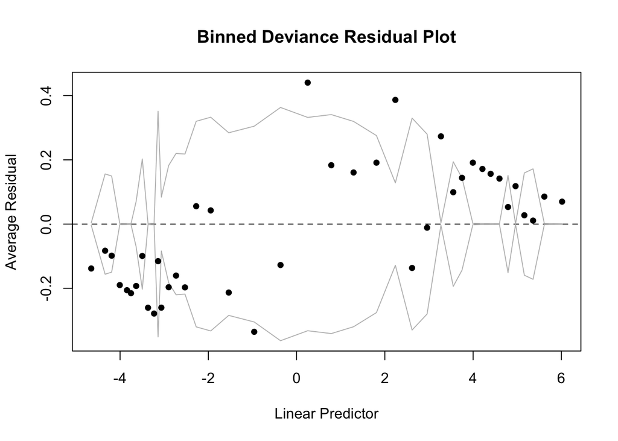

```r
LinearPred<-predict(final)
DevianceRes<-residuals(final)
binnedplot(LinearPred, DevianceRes,xlab="Linear Predictor",ylab="Average Residual",main="Binned Deviance Residual Plot")
```

2. If the model contains a discrete quantitative explanatory variable, test for nonlinearity by specifying a model that treats this variable as a factor (e.g., using dummy regressors), and comparing that model via a likelihood-ratio test to the model that specifies that the variable has a linear effect. (If there is more than one discrete quantitative explanatory variable, then begin with a model that treats all of them as factors, contrasting this with a sequence of models that specifies a linear effect for each such variable in turn.) Note that this is analogous to the approach for testing for nonlinearity in a linear model with discrete explanatory variables described in Section 12.4.1.

```r
test1 = glm(vote ~ statusquo + education + population, family = binomial, data = Chile)
test2 = glm(vote ~ statusquo + education + as.factor(population), family = binomial, data = Chile)

anova(test1, test2, test = "Chisq")
```

```
## Analysis of Deviance Table
##
## Model 1: vote ~ statusquo + education + population
## Model 2: vote ~ statusquo + education + as.factor(population)
##   Resid. Df Resid. Dev Df Deviance Pr(>Chi)
## 1      2426     1245.8
## 2      2418     1237.0  8   8.8151   0.3581
```

I think these both options work because the p-values shown in anova table are large.

3. Explore the use of the log-log and complementary-log-log links as alternatives to the logit link for this regression. Comparing deviances under the different links, which link appears to best represent the data?

```r
cloglog_model = glm(vote ~ sex + statusquo + education, family = binomial(link = "cloglog"), data = part_chile_set)
final$deviance
```

```
## [1] 708.2366
```

```r
cloglog_model$deviance
```

```
## [1] 770.2568
```

```r
finalProbit$deviance
```

```
## [1] 708.8987
```

Long (1990, 1997) investigates factors affecting the research productivity of doctoral students in biochemistry. Long’s data (on 915 biochemists) are in the file `Long.txt`. The response variable in this investigation, `art`, is the number of articles published by the student during the last three years of his or her PhD programme.

The explanatory variables are as follows:

*Explanatory variables in `long.txt` data*

[output not shown]

1. Examine the distribution of the response variable. Based on this distribution, does it appear promising to model these data by linear least-squares regression, perhaps after transforming the response? Explain your answer.

```r
long <- read.table("./Datasets/Long.txt")
model_fit4a <- lm(art ~ fem + mar + kid5 + phd + ment, data = long)
summary(model_fit4a)
```

```
##
## Call:
## lm(formula = art ~ fem + mar + kid5 + phd + ment, data = long)
##
## Residuals:
##     Min      1Q  Median      3Q     Max
## -5.0209 -1.2358 -0.4125  0.7517 14.8409
##
## Coefficients:
##              Estimate Std. Error t value Pr(>|t|)
## (Intercept)  1.334256   0.240906   5.538 3.99e-08 ***
## fem         -0.380886   0.128139  -2.972  0.00303 **
## mar          0.263198   0.145423   1.810  0.07064 .
## kid5        -0.291442   0.090919  -3.206  0.00140 **
## phd         -0.011368   0.063664  -0.179  0.85833
## ment         0.061495   0.006605   9.310  < 2e-16 ***
## ---
## Signif. codes:  0 '***' 0.001 '**' 0.01 '*' 0.05 '.' 0.1 ' ' 1
##
## Residual standard error: 1.822 on 909 degrees of freedom
## Multiple R-squared:  0.1104, Adjusted R-squared:  0.1055
## F-statistic: 22.55 on 5 and 909 DF,  p-value: < 2.2e-16
```

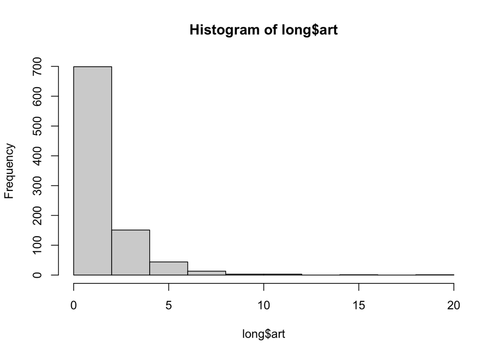

```r
hist(long$art)
```

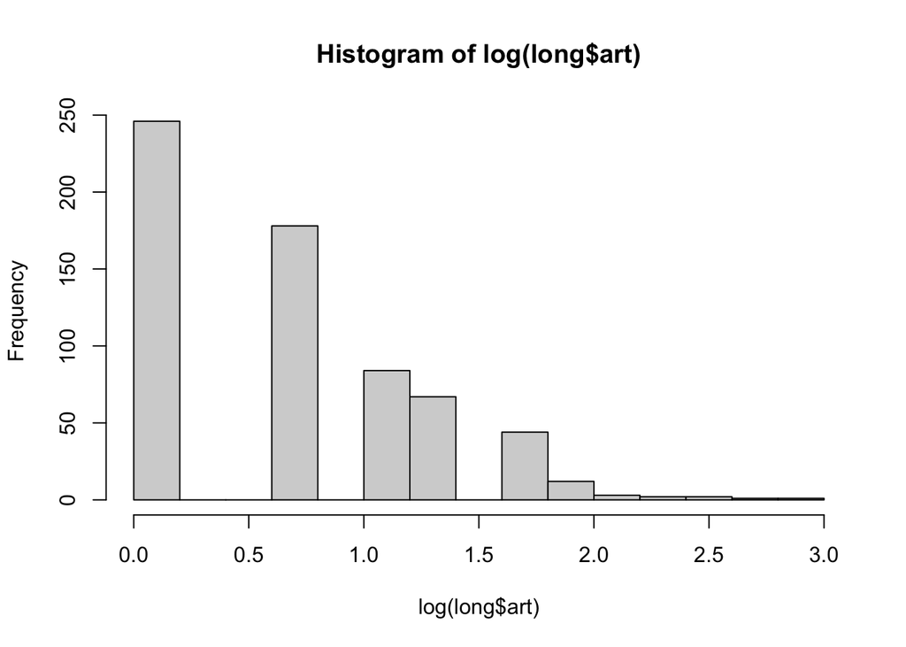

```r
hist(log(long$art))
```

We can find the distribution in log-histogram is discrete and skewed, and the distribution is likely to be a Poisson and the linear least squares regression may not be appropriate. (b) Following Long, perform a Poisson regression of art on the explanatory variables. What do you conclude from the results of this regression?

```r
model_fit4b <- glm(art ~ fem + mar + kid5 + phd + ment, family = "poisson", data = long)
summary(model_fit4b)
```

```
##
## Call:
## glm(formula = art ~ fem + mar + kid5 + phd + ment, family = "poisson",
##     data = long)
##
## Deviance Residuals:
##     Min       1Q   Median       3Q      Max
## -3.5672  -1.5398  -0.3660   0.5722   5.4467
##
## Coefficients:
##              Estimate Std. Error z value Pr(>|z|)
## (Intercept)  0.304619   0.102980   2.958   0.0031 **
## fem         -0.224594   0.054613  -4.112 3.92e-05 ***
## mar          0.155243   0.061374   2.529   0.0114 *
## kid5        -0.184883   0.040127  -4.607 4.08e-06 ***
## phd          0.012822   0.026397   0.486   0.6271
## ment         0.025543   0.002006  12.733  < 2e-16 ***
## ---
## Signif. codes:  0 '***' 0.001 '**' 0.01 '*' 0.05 '.' 0.1 ' ' 1
##
## (Dispersion parameter for poisson family taken to be 1)
##
##     Null deviance: 1817.4  on 914  degrees of freedom
## Residual deviance: 1634.4  on 909  degrees of freedom
## AIC: 3314.1
##
## Number of Fisher Scoring iterations: 5
```

The coefficients phd is not significant and the p-value is high, it may not be relevant.  
Interpretations to the statistically significant coefficients using Divide by 4 rule: 1/4:  
The coefficient Intercept: $exp(\hat{\beta}_0)$=1.3561083 means that the odds of articles published by the student are 1.3561083, when the scale of fem, mar, kid5, phd and ment are all 0 unit.

The coefficient mar: $exp(\hat{\beta}_2)$=1.1679420 means that the Number of articles published by the student are 1.1679420 times bigger, when Variable mar increase by 1 unit, and when fem, kid5, phd and ment are fixed.

The coefficient phd: $exp(\hat{\beta}_4)$=1.0129045 means that the Number of articles published by the student are 1.0129045 units bigger, when Variable phd increase by 1 unit, and when fem, mar, kid5 and ment are fixed.

The coefficient ment: $exp(\hat{\beta}_5)$=1.0258718 means that the Number of articles published by the student are 1.0258718 units bigger, when Variable ment increase by 1 unit, and when fem, mar, kid5 and phd are fixed.

3. Perform regression diagnostics on the model fit in the previous question. If you identify any problems, try to deal with them. Are the conclusions of the research altered?

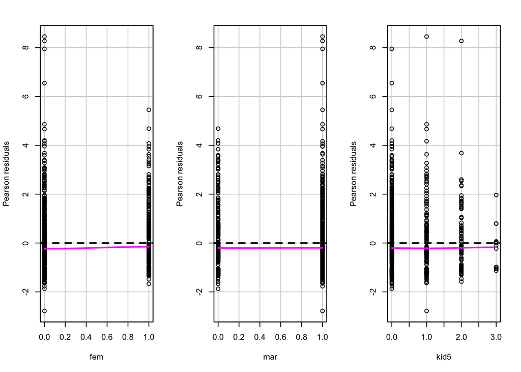

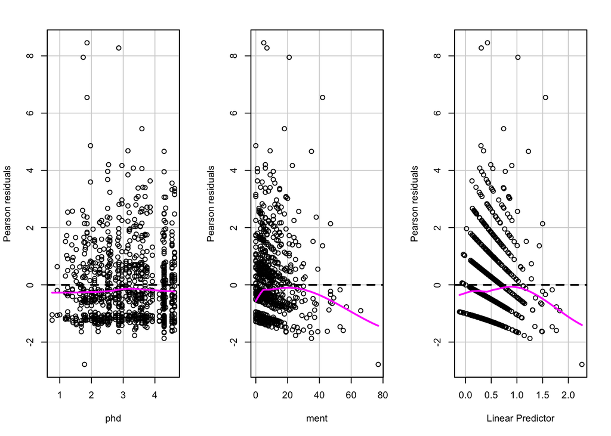

```
##      Test stat Pr(>|Test stat|)
## fem     0.0000           1.0000
## mar     0.0000           1.0000
## kid5    0.3888           0.5329
## phd     2.3358           0.1264
## ment   36.3491         1.65e-09 ***
## ---
## Signif. codes:  0 '***' 0.001 '**' 0.01 '*' 0.05 '.' 0.1 ' ' 1
```

```r
residualPlots(model_fit4b, layout = c(1,3))
```

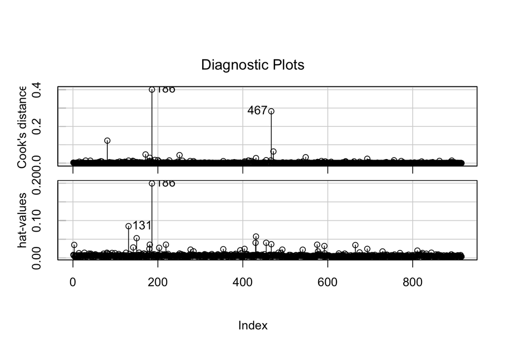

```r
infIndexPlot(model_fit4b, var = c("cook","hat"))
```

```r
# We find 186 and 467
compareCoefs(model_fit4b, update(model_fit4b, subset = -c(186,467)))
```

```
## Calls:
## 1: glm(formula = art ~ fem + mar + kid5 + phd + ment, family = "poisson",
##   data = long)
## 2: glm(formula = art ~ fem + mar + kid5 + phd + ment, family = "poisson",
##   data = long, subset = -c(186, 467))
##
##             Model 1 Model 2
## (Intercept)   0.305   0.284
## SE            0.103   0.104
##
## fem         -0.2246 -0.2124
## SE           0.0546  0.0548
##
## mar          0.1552  0.1396
## SE           0.0614  0.0616
##
## kid5        -0.1849 -0.1650
## SE           0.0401  0.0401
##
## phd          0.0128  0.0155
## SE           0.0264  0.0273
##
## ment        0.02554 0.02600
## SE          0.00201 0.00224
##
```

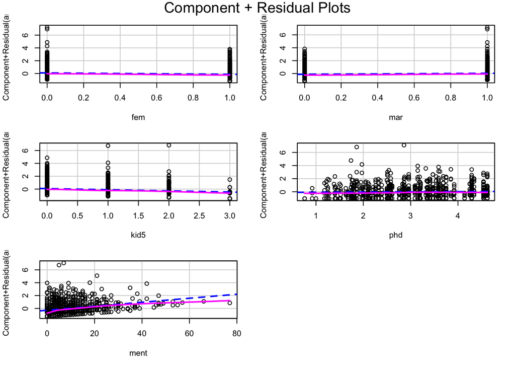

```r
crPlots(model_fit4b)
```

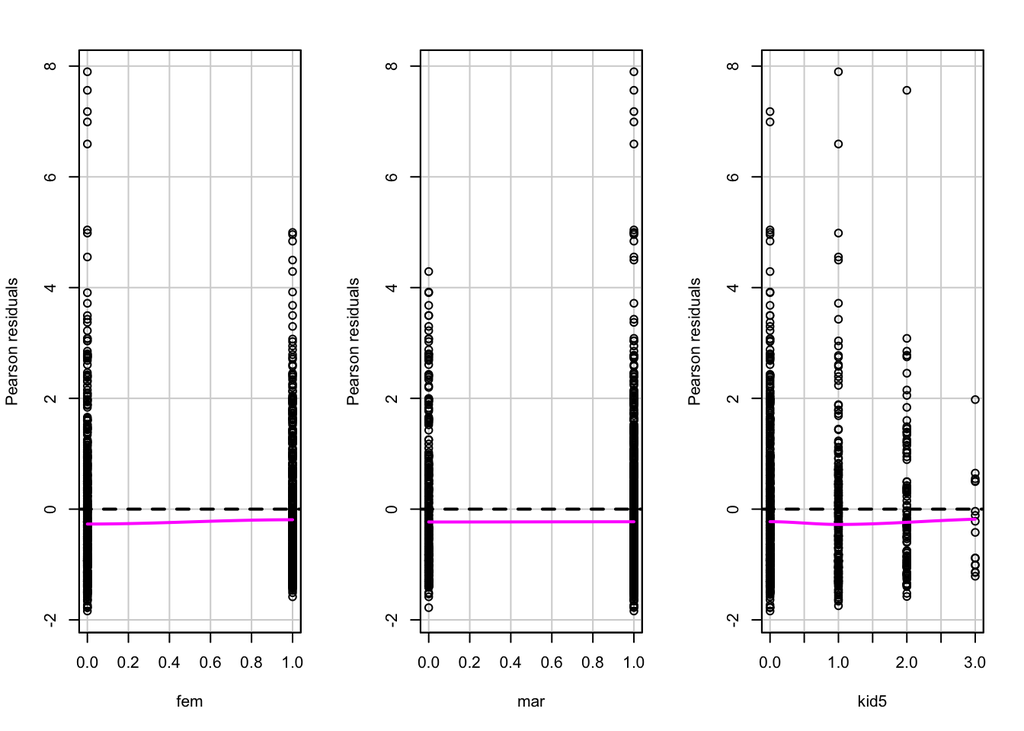

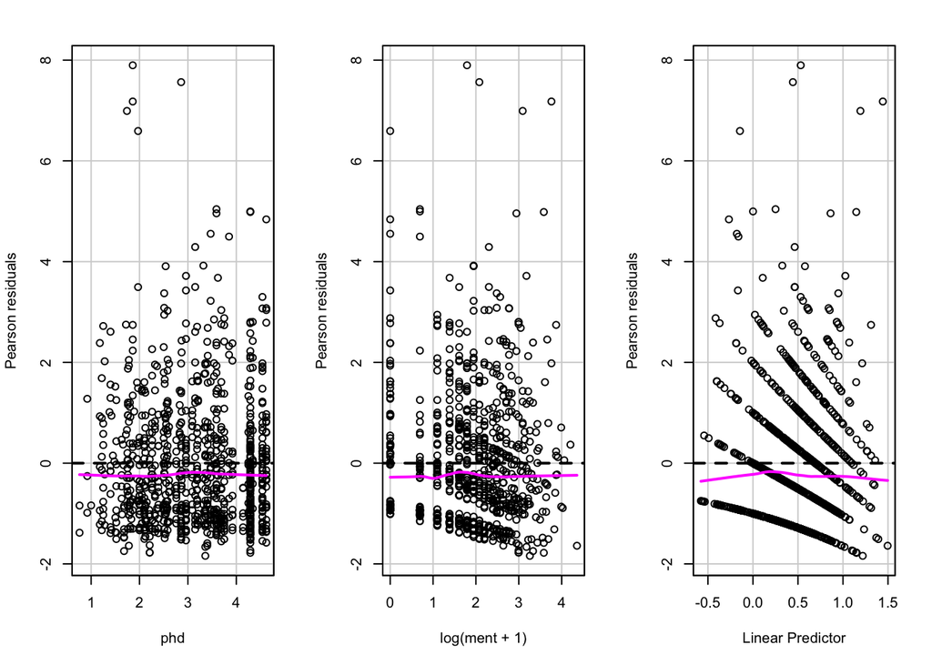

```
##               Test stat Pr(>|Test stat|)
## fem              0.0000          1.00000
## mar              0.0000          1.00000
## kid5             0.6710          0.41271
## phd              0.4401          0.50707
## log(ment + 1)    2.9392          0.08645 .
## ---
## Signif. codes:  0 '***' 0.001 '**' 0.01 '*' 0.05 '.' 0.1 ' ' 1
```

```r
newModel <- glm(art ~ fem + mar + kid5 + phd + log(ment+1), family = "poisson", data = long)
residualPlots(newModel, layout = c(1,3))
```

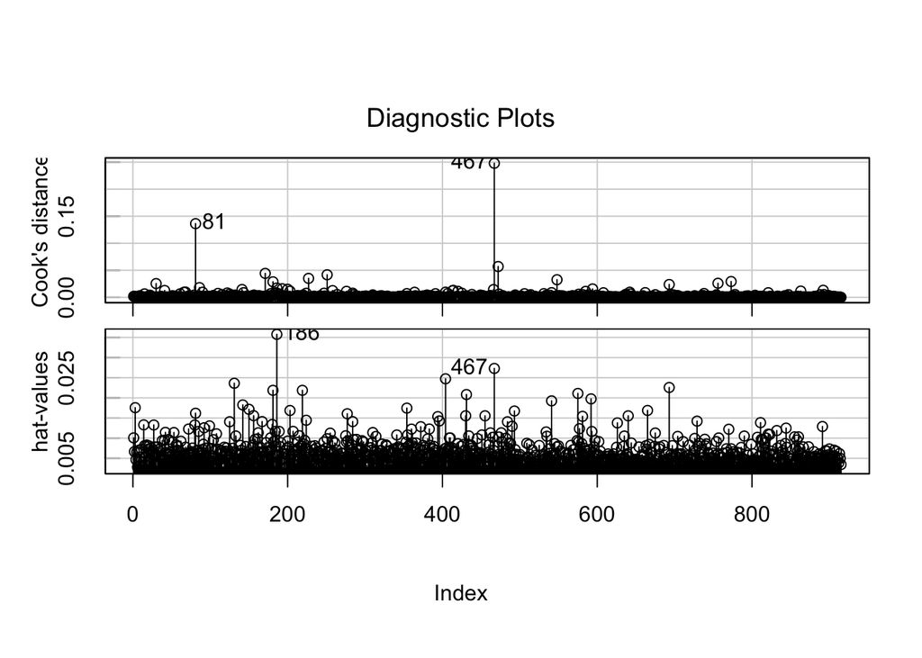

```r
infIndexPlot(newModel, var = c("cook","hat"))
```

```r
compareCoefs(newModel, update(newModel, subset = -c(81, 186,467)))
```

```
## Calls:
## 1: glm(formula = art ~ fem + mar + kid5 + phd + log(ment + 1), family =
##   "poisson", data = long)
## 2: glm(formula = art ~ fem + mar + kid5 + phd + log(ment + 1), family =
##   "poisson", data = long, subset = -c(81, 186, 467))
##
##               Model 1 Model 2
## (Intercept)   -0.0943 -0.1472
## SE             0.1110  0.1122
##
## fem           -0.2339 -0.2023
## SE             0.0545  0.0549
##
## mar            0.1677  0.1310
## SE             0.0613  0.0619
##
## kid5          -0.1722 -0.1352
## SE             0.0399  0.0401
##
## phd           -0.0230  0.0102
## SE             0.0272  0.0279
##
## log(ment + 1)  0.3755  0.3411
## SE             0.0296  0.0303
##
```

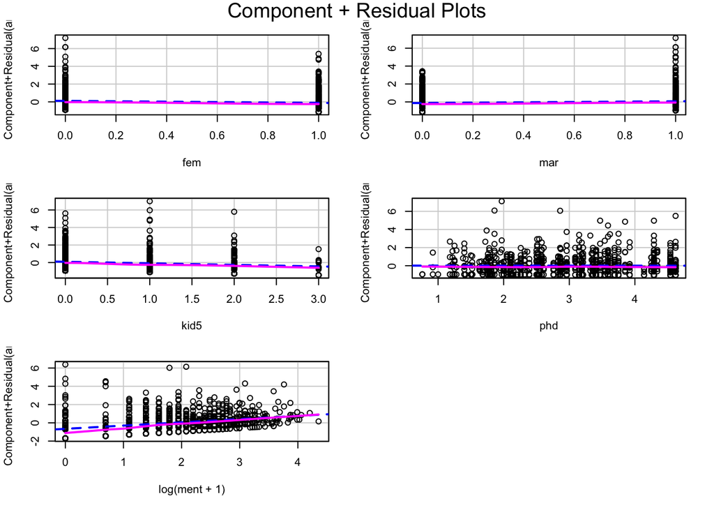

```r
crPlots(newModel)
```

Now we have following conclusions: 1. the residual plots for all predictor variables have a red line around 0, the mean of those variables in the model are close to 0. 2. For the possible three influential points, removing them will not change a lot and then no influential points. 3. In the last plot, for each predictor variable in the model, their component+residual centered at line 0. Hence, there’s no non-linearity result in our model.  
After comparing the results, no conclusions alter but we can drop these three possible influetial points.

4. Refit Long’s model allowing for overdispersion (using a quasi-Poisson or negative-binomial model). Does this make a difference to the results?

```r
model_fit4d1 <- glm(art ~ fem + mar + kid5 + phd + ment, family = "quasipoisson", data = long)
summary(model_fit4d1)
```

```
##
## Call:
## glm(formula = art ~ fem + mar + kid5 + phd + ment, family = "quasipoisson",
##     data = long)
##
## Deviance Residuals:
##     Min       1Q   Median       3Q      Max
## -3.5672  -1.5398  -0.3660   0.5722   5.4467
##
## Coefficients:
##              Estimate Std. Error t value Pr(>|t|)
## (Intercept)  0.304619   0.139271   2.187 0.028979 *
## fem         -0.224594   0.073860  -3.041 0.002427 **
## mar          0.155243   0.083003   1.870 0.061759 .
## kid5        -0.184883   0.054268  -3.407 0.000686 ***
## phd          0.012822   0.035699   0.359 0.719552
## ment         0.025543   0.002713   9.415  < 2e-16 ***
## ---
## Signif. codes:  0 '***' 0.001 '**' 0.01 '*' 0.05 '.' 0.1 ' ' 1
##
## (Dispersion parameter for quasipoisson family taken to be 1.829006)
##
##     Null deviance: 1817.4  on 914  degrees of freedom
## Residual deviance: 1634.4  on 909  degrees of freedom
## AIC: NA
##
## Number of Fisher Scoring iterations: 5
```

```r
model_fit4d2 <- glm.nb(art ~ fem + mar + kid5 + phd + ment, data = long)
summary(model_fit4d2)
```

```
##
## Call:
## glm.nb(formula = art ~ fem + mar + kid5 + phd + ment, data = long,
##     init.theta = 2.264387444, link = log)
##
## Deviance Residuals:
##     Min       1Q   Median       3Q      Max
## -2.1678  -1.3617  -0.2806   0.4476   3.4524
##
## Coefficients:
##              Estimate Std. Error z value Pr(>|z|)
## (Intercept)  0.256143   0.137345   1.865 0.062188 .
## fem         -0.216418   0.072636  -2.979 0.002887 **
## mar          0.150490   0.082097   1.833 0.066790 .
## kid5        -0.176415   0.052813  -3.340 0.000837 ***
## phd          0.015272   0.035872   0.426 0.670313
## ment         0.029082   0.003214   9.048  < 2e-16 ***
## ---
## Signif. codes:  0 '***' 0.001 '**' 0.01 '*' 0.05 '.' 0.1 ' ' 1
##
## (Dispersion parameter for Negative Binomial(2.2644) family taken to be 1)
##
##     Null deviance: 1109.0  on 914  degrees of freedom
## Residual deviance: 1004.3  on 909  degrees of freedom
## AIC: 3135.9
##
## Number of Fisher Scoring iterations: 1
##
##
##               Theta:  2.264
##           Std. Err.:  0.271
##
##  2 x log-likelihood:  -3121.917
```

Comparing the summary tables above, the coefficients for each predictor variables are closer, but the deviance for the negative-binomial model is much lower than the quasi-Poisson model. Hence, I prefer the negative-binomial model.